# Generating random points within a polygon

# Generate a grid of points

The `st_make_grid()` function will generate a grid that covers the bounding box of a specified layer.

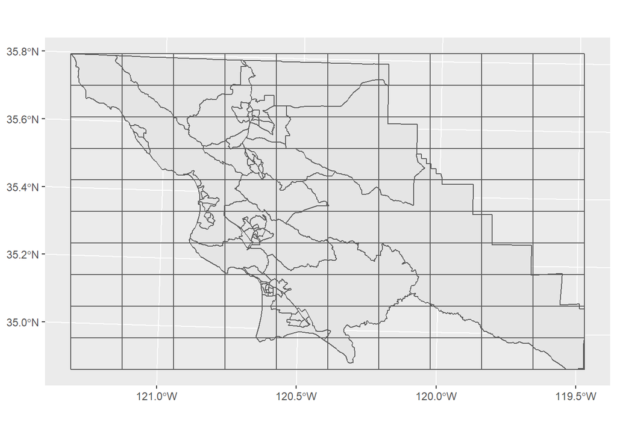

```r
grid_squares <- st_make_grid(tracts)

ggplot() +
  geom_sf(data = tracts) +
  geom_sf(data = grid_squares,
          fill = NA)
```

By default, the grid sizes are selected so to make a 10x10 grid. I can also specific the number of grid cells I want in each direction. Here is a 15x12 grid.

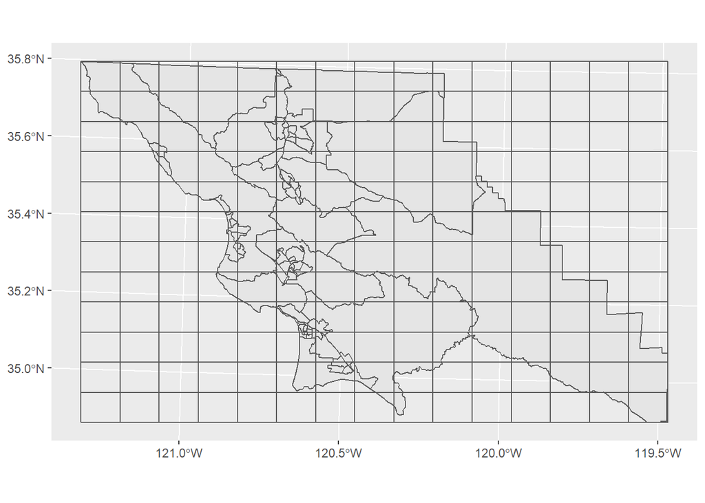

```r
grid_squares <- st_make_grid(tracts, n = c(15, 12))

ggplot() +
  geom_sf(data = tracts) +
  geom_sf(data = grid_squares,
          fill = NA)
```

It’s more likely that you’ll care more about the cell size than about how many cells are in the bounding box. You can also specify the cell height and width instead of the number of cells. Here is a grid of cells that are 5 miles by 5 miles (there are 5280 feet in a mile).

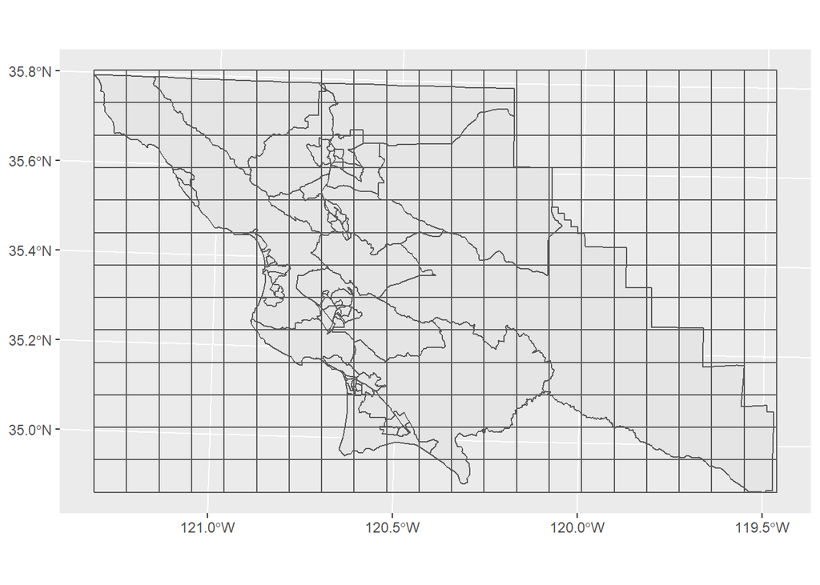

```r
grid_squares <- st_make_grid(tracts, cellsize = c(5 * 5280, 5 * 5280))

ggplot() +
  geom_sf(data = tracts) +
  geom_sf(data = grid_squares,
          fill = NA)
```

You can also make a hexagonal grid by setting `square = FALSE`.

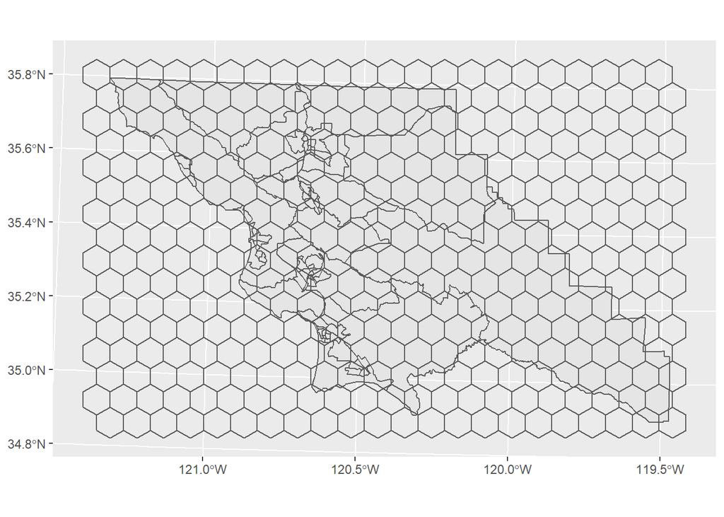

```r
grid_hex <- st_make_grid(tracts, cellsize = c(5 * 5280, 5 * 5280), square = FALSE)

ggplot() +
  geom_sf(data = tracts) +
  geom_sf(data = grid_hex,
          fill = NA)
```

If you want points instead of polygons, you can set `what = corners` or `what = centers`.

Here is a set of points at the centers of a 5-mile by 5-mile hex grid.

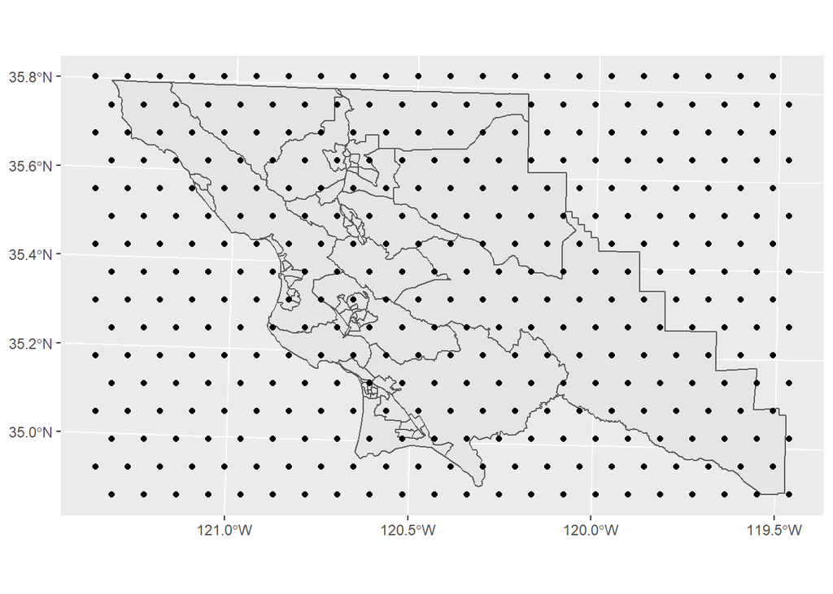

```r
grid_hex_pts <- st_make_grid(tracts,
                             cellsize = c(5 * 5280, 5 * 5280),
                             square = FALSE,
                             what = "centers")

ggplot() +
  geom_sf(data = tracts) +
  geom_sf(data = grid_hex_pts,
          fill = NA)
```

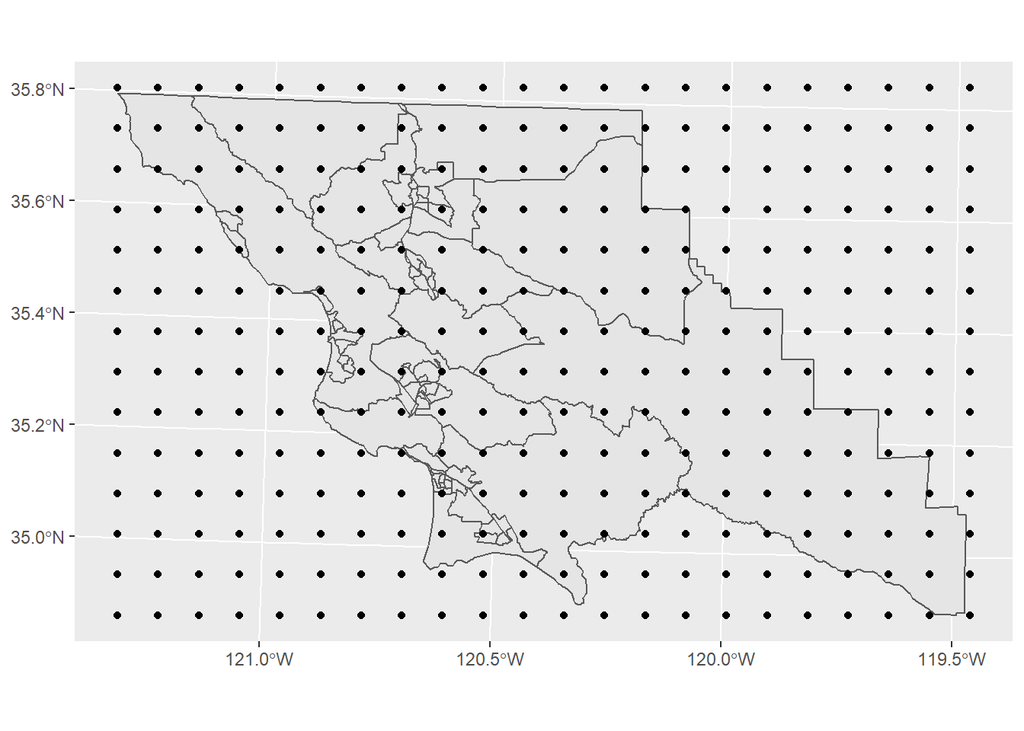

```r
grid_hex_pts <- st_make_grid(tracts,
                             cellsize = c(5 * 5280, 5 * 5280),
                             what = "corners")

ggplot() +
  geom_sf(data = tracts) +
  geom_sf(data = grid_hex_pts,
          fill = NA)
```

Here is a set of points at the corners of a hex grid.

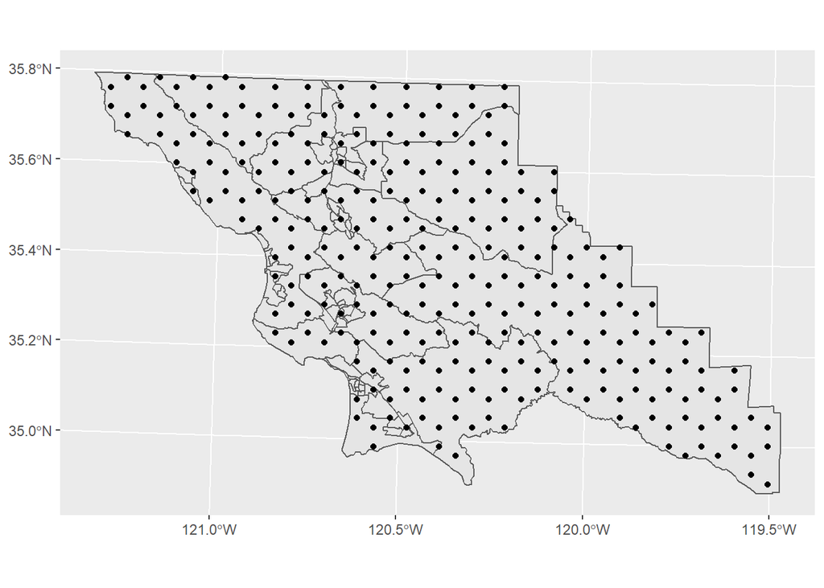

```r
grid_hex_pts <- st_make_grid(tracts,
                             cellsize = c(5 * 5280, 5 * 5280),
                             square = FALSE,
                             what = "corners")

ggplot() +
  geom_sf(data = tracts) +
  geom_sf(data = grid_hex_pts,
          fill = NA)
```

In this case, the layer of points was automatically clipped to the polygon boundary, where all the other grids filled the whole bounding box. I do not have an explanation for that.

You can easily clip any grid to the boundaries of a polygon though.

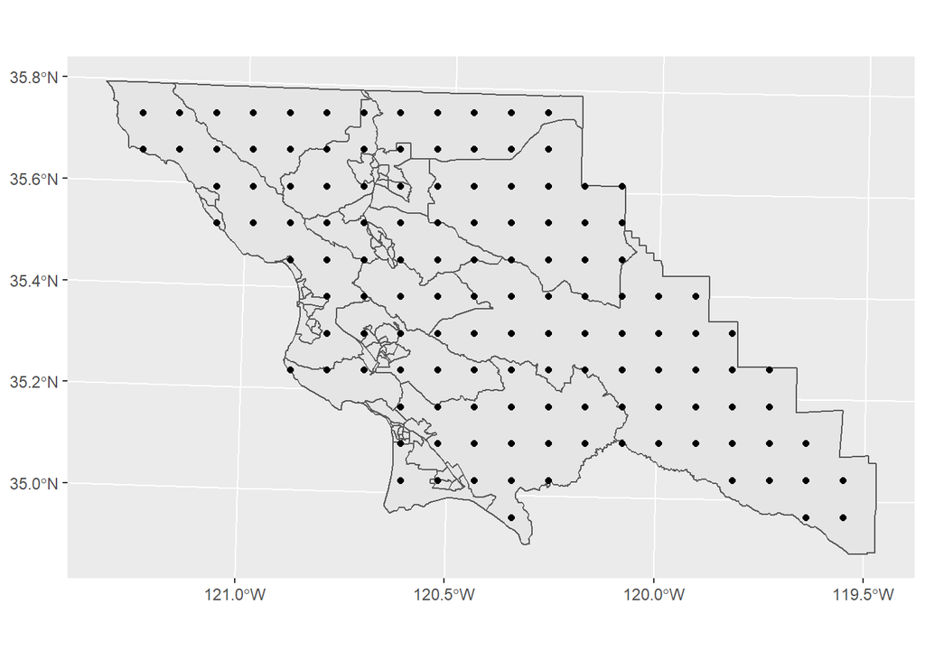

```r
grid_hex_pts <- st_make_grid(tracts,
                             cellsize = c(5 * 5280, 5 * 5280),
                             what = "corners") %>%
  st_as_sf() %>%
  st_filter(tracts)

ggplot() +
  geom_sf(data = tracts) +
  geom_sf(data = grid_hex_pts,
          fill = NA)
```